# Economie internationale

Chapitre 2: Theories du commerce international (Smith, Ricardo)

Thomas Delcey

thomas.delcey@ube.fr

Université de Bourgogne

# Introduction

## Problème du chapitre

**Dans le précédent chapitre:**

- Histoire des mondialisations jusqu’à aujourd’hui
- Les facteurs favorisant l’augmentation des échanges internationaux

**Mais …**

- Pourquoi des pays échangent-ils alors qu’ils pourraient produire eux-memes ?
- Pourquoi certains pays exportent-ils plutôt des biens que d’autres ?
- Qui gagne et qui perd dans la spécialisation ?

## Ce chapitre

- On étudie les théories classiques du commerce international
  - Avantage absolu (Adam Smith)
  - Avantage comparatif (David Ricardo)
  - Limites et implications

Ces théories, et leurs critiques, sont à la base de la pensée moderne sur le commerce international.

## Qu’est-ce qu’une théorie ?

**Qu’est-ce qu’une théorie du commerce international**

- Une théorie c’est une explication simplifiée de la réalité
- Raisonnement abstrait
- Raisonnement logique
- Confrontation aux faits

# L’avantage absolu (Adam Smith)

## Contexte historique

[figure not shown]

Page de titre du Traité d’Economie Politique (1615) par Antoine de Montchrétien

**Le mercantilisme**

- Pensée économique contemporaine aux colonisations occidentales (XVIe-XVIIIe siècles).
- Prône la puissance de l’Etat par l’accumulation de richesses.
- Une balance commerciale excédentaire est un objectif prioritaire.
- Favorise les politiques protectionnistes pour limiter les importations.

## Adam Smith (1723-1790)

[figure not shown]

Portrait d’Adam Smith (1723-1790)

[figure not shown]

Page de titre de “La richesse des nations”, publié en 1776

## Les gains a l’echange chez Smith

> It is not from the benevolence of the butcher, the brewer, or the baker that we expect our dinner, but from their regard to their own interest. We address ourselves, not to their humanity, but to their self-love, and never talk to them of our own necessities, but of their advantages.

Adam Smith (1776)

**Concepts clefs d’Adam Smith**

- Division du travail
- Spécialisation
- Gains mutuels à l’échange

## L’avantage absolu de Smith

**Définition**

Un pays a un **avantage absolu** s’il peut produire un bien avec moins de ressources (travail, capital, etc.) que les autres pays.

> The natural advantages which one country has over another in producing particular commodities are sometimes so great that it is acknowledged by all the world to be in vain to struggle with them. By means of glasses, hot-beds, and hot-walls, very good grapes can be raised in Scotland, and very good wine, too, can be made of them—at about thirty times the expense for which at least equally good wine can be brought from foreign countries. Would it be a reasonable law to prohibit the importation of all foreign wines merely to encourage the making of claret and Burgundy in Scotland? […] As long as the one country has those advantages, and the other wants them, it will always be more advantageous for the latter rather to buy of the former than to make.

Adam Smith (1776)

## Exemple

Unité par travailleur par an

|  | France | Écosse |
| --- | --- | --- |
| Vin | 400 | 50 |
| Whisky | 50 | 100 |

**Problème**

Supposons que la demande pour chaque bien soit de 400 unités par an.

1. En autarcie, quelle serait les besoins en travail dans chaque pays ?
2. Que serait la production totale si chaque pays se spécialisait dans le bien où il est le plus productif avec cette main-d’œuvre ?

## Exemple

Unité par travailleur par an

|  | France | Écosse |
| --- | --- | --- |
| Vin | 400 | 50 |
| Whisky | 50 | 100 |

**En autarcie, combien de travailleurs sont nécessaires ?**

- France: 1 pour le vin (400/400) + 8 pour le whisky (400/50), soit 9 travailleurs
- Écosse: 8 pour le vin (400/50) + 4 pour le whisky (400/100), soit 12 travailleurs
- Production totale: 800 unités de vin et 800 unités de whisky

## Exemple

Unité par travailleur par an

|  | France | Écosse |
| --- | --- | --- |
| Vin | 400 | 50 |
| Whisky | 50 | 100 |

**Si les pays se spécialisent ?**

- France: 9 travailleurs peuvent produire 3600 (9*400) unités de vin
- Écosse: 12 travailleurs produisent 1200 (12*100) unités de whisky
- Production totale: 3600 unités de vin et 1200 unités de whisky

La spécialisation augmente la production totale dans les deux secteurs

## Les avantages absolus

**En résumé**

- Un pays a un **avantage absolu** dans un secteur s’il est plus productif que les autres pays dans ce secteur
- Si deux pays ont des avantages absolus différents, la spécialisation permet d’augmenter la production totale et d’obtenir des gains mutuels à l’échange

Mais si un pays est meilleur dans la production de **tous** les biens, l’avantage absolu ne suffit pas à expliquer l’echange

# 2. L’avantage comparatif (Ricardo)

## David Ricardo

**Qui est David Ricardo ?**

- Économiste et homme politique britannique
- Principal ouvrage “Principes de l’économie politique et de l’impôt” (1817)
- Poursuit et affine les idées d’Adam Smith

[figure not shown]

Portrait de David Ricardo (1772-1823)

## Contexte historique

- Blocus de la Grande-Bretagne par Napoléon (1806-1814)
  - Importation de céréales limitée
  - Production nationale se développe et les prix augmentent
- Fin du blocus et débat parlementaire sur l’importation des céréales
  - Les défenseurs des agriculteurs demandent des restrictions sur les importations
  - Les libéraux, comme Ricardo, défendent une politique de libre-échange pour favoriser les exportations manufacturières
- Les *Corn Laws* sont votés en 1815 mettent en place un protectionnisme agricole.
  - Si le prix des céréales descends en dessous de 80 scillings le quarter (environ 12kg), les importations sont interdites
- David Ricardo milite contre ces lois et développe sa théorie de l’avantage comparatif en réponse (en 1846, les *Corn Laws* sont abrogées).

## L’avantage comparatif de Ricardo

**Principe intuitif**

Même si un pays est moins productif dans tous les secteurs (aucun avantage absolu), il peut y avoir des gains mutuels à l’échange si ce pays se spécialise dans le secteur où son désavantage est le moins grand.

**Définition**

- Un pays a un avantage comparatif dans la production d’un bien si la **productivité relative** d’un bien est plus grande que dans un autre pays.
- La productivité relative est une comparaison de la productivité d’un secteur par rapport à un autre dans un pays donné.

## Exemple

Unité par travailleur par an

|  | France | Écosse |
| --- | --- | --- |
| Vin | 400 | 50 |
| Whisky | 200 | 100 |

Productivité relative

|  | France | Écosse |
| --- | --- | --- |
| Vin / Whisky | 400/200 = 2 | 50/100 = 0.5 |
| Whisky / Vin | 200/400 = 0.5 | 100/50 = 2 |

- En France, on peut produire 2 unités de vin pour chaque unité de whisky
- En Ecosse, on peut produire 2 unités de whisky pour chaque unité de vin
- La France a un avantage comparatif dans la production de vin, et l’Écosse dans la production de whisky, *même si la France est plus productive dans les deux secteurs*

## Exemple

Unité par travailleur par an

|  | France | Écosse |
| --- | --- | --- |
| Vin | 400 | 50 |
| Whisky | 200 | 100 |

**Problème**

Supposons que la demande pour chaque bien soit de 400 unités par an.

1. En autarcie, quelle serait les besoins en travail dans chaque pays ?
2. Que serait la production totale si chaque pays se spécialisait dans le bien où il est le plus productif avec cette main-d’œuvre ?

## Exemple

Unité par travailleur par an

|  | France | Écosse |
| --- | --- | --- |
| Vin | 400 | 50 |
| Whisky | 200 | 100 |

**En autarcie, combien de travailleurs sont nécessaires ?**

- France: 1 pour le vin (400/400) + 2 pour le whisky (400/200), soit 3 travailleurs
- Écosse: 8 pour le vin (400/50) + 4 pour le whisky (400/100), soit 12 travailleurs
- Production totale: 800 unités de vin et 800 unités de whisky

## Exemple

Unité par travailleur par an

|  | France | Écosse |
| --- | --- | --- |
| Vin | 400 | 50 |
| Whisky | 200 | 100 |

**Si les pays se spécialisent ?**

- France: 3 travailleurs peuvent produire 1200 (3*400) unités de vin
- Écosse: 12 travailleurs produisent 1200 (12*100) unités de whisky
- Production totale: 1200 unités de vin et 1200 unités de whisky

La spécialisation augmente la production totale dans les deux secteurs alors même que l’écosse n’a aucun avantage absolu.

## Les avantages comparatifs

**En résumé**

- Un pays a un **avantage comparatif** si sa productivité relative d’un bien est plus grande que dans un autre pays
- Les pays échangent car ils ont des productivités différentes
  - Condition non discutée ici: la condition des prix.
- Même si un pays a des productivités absolus plus faibles, il a intérêt à se spécialiser dans le secteur où son désavantage est le moins grand
- Avec cette théorie, on ne regarde pas seulement ce qu’on gagne (avantage absolu), mais aussi ce qu’on perd (coût d’opportunité)
- Les pays bénéficient d’une hausse de la production totale et des revenus

## Implications selon Ricardo

> Under a system of perfectly free commerce, each country naturally devotes its capital and labour to such employments as are most beneficial to each. This pursuit of individual advantage is admirably connected with the universal good of the whole. By stimulating industry, by rewarding ingenuity, and by using most efficaciously the peculiar powers bestowed by nature, it distributes labour most effectively andmost economically: while, by increasing the general mass of productions, it diffuses general benefit, and binds together by one common tie of interest and intercourse, the universal society of nations throughout the civilized world. It is this principle which determines that wine shall be made in France and Portugal, that corn shall be grown in America and Poland, and that hardware and other goods shall be manufactured in England.

David Ricardo (1817) *On the Principles of Political Economy, and Taxation*

## Limites de l’argument

- L’argument de Ricardo est logiquement vrai et se généralisent à plusieurs pays et plusieurs biens
- Mais il repose sur des hypothèses implicites fortes.

**Hypothèses implicites**

- Mobilité parfaite du travail entre secteurs dans un même pays.
- Mobilité parfaite du capital entre secteurs.
- Les avantages comparatifs ne changent pas dans le temps.

## Confrontation aux faits

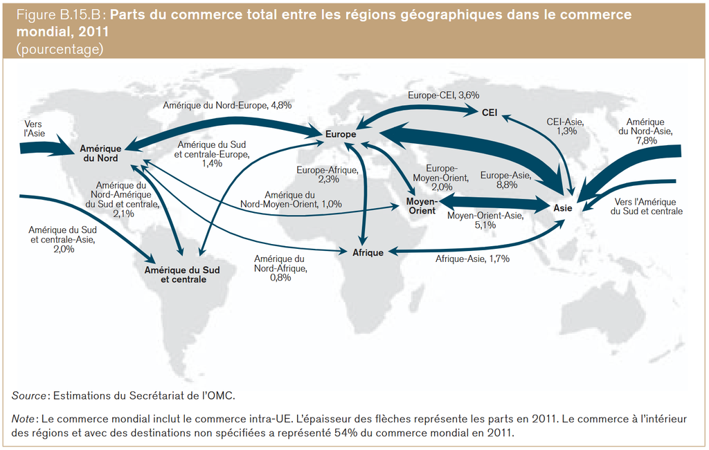

**Quelques exemples**

- La plupart des échanges se font entre pays avec des niveaux de productivité similaires
- Spécialisation $\neq$ développement économique reussi
- Les exemples d’ouvertures commerciales reussies ont impliqué des mesures protectionnistes pour soutenir les secteurs naissants (ex: Corée du Sud, Taiwan, Chine).

## Conclusion

**En résumé**

- Smith: avantages absolus
- Ricardo: avantages comparatifs
- Justification du libre-échange par le gain mutuel à l’échange
- Limites des théories classiques

## Références

Organisation mondiale du commerce. 2013. *Rapport sur le commerce mondial 2013 : Facteurs déterminant l’avenir du commerce mondial*. Genève: Organisation mondiale du commerce. https://www.wto.org/french/res_f/booksp_f/world_trade_report13_f.pdf.

Ricardo, David. 1817. *On the Principles of Political Economy, and Taxation*. Project Gutenberg. https://www.gutenberg.org/ebooks/33310.

Smith, Adam. 1776. *An Inquiry into the Nature and Causes of the Wealth of Nations*. Project Gutenberg. https://www.gutenberg.org/ebooks/3300.